# Proyecto

Alvaro

2024-11-14

```r
library(rio)
```

```r
library(readxl)
data1 <- read_excel("capitulo100-600.xlsx")
data2 <- read_excel("capitulo300-400.xlsx")
library(dplyr)
# Variables de interés de data1
subset_data1 <- select(data1, P601, P602_5, UBIGEO)

# Variables de interés de data2
subset_data2 <- select(data2, P409, P407_4, P431, P435, P301, P303, P306, ESTRATOSOCIO, P209, P210_A)
```

```r
# Expande `subset_data1` para igualar el número de filas de `subset_data2
expanded_data1 <- subset_data1 %>%
  slice(rep(1:n(), length.out = nrow(subset_data2)))
```

```r
# Combina las tablas por columnas
combined_data <- bind_cols(expanded_data1, subset_data2)
```

```r
class(combined_data$P409)
```

```
## [1] "character"
```

```r
# Convertir P409 a numérico (si es necesario)
combined_data$P409 <- as.numeric(combined_data$P409)
# Recodificar la variable P409 de números a las categorías de texto
combined_data$P409_recoded <- recode(combined_data$P409,
                                     `1` = "Diariamente",
                                     `2` = "Frecuentemente",
                                     `3` = "Ocasionalmente",
                                     `4` = "Ocasionalmente",
                                     `5` = "Nunca o casi nunca",
                                     `6` = "Nunca o casi nunca")

# Convertirla a ordinal
combined_data$P409_recoded_ordinal <- factor(
  combined_data$P409_recoded,
  levels = c("Nunca o casi nunca", "Ocasionalmente", "Frecuentemente", "Diariamente"),  # Orden deseado
  ordered = TRUE  # Indica que es un factor ordinal
)

# Eliminar filas con valores NA en la variable recodificada ordinal
combined_data_clean <- combined_data[!is.na(combined_data$P409_recoded_ordinal), ]

# Eliminar columnas sobrantes
combined_data_clean <- combined_data_clean %>%
  select(-P409, -P409_recoded)

# Cambio de nombre de la variable dependiente
colnames(combined_data_clean)[colnames(combined_data_clean) == "P409_recoded_ordinal"] <- "habito_lectura"

# Cambiar el nombre de la base de datos
data <- combined_data_clean

# Eliminar bases inútiles
rm(combined_data_clean)
rm(combined_data)
rm(data1)
rm(data2)
rm(expanded_data1)
rm(subset_data1)
rm(subset_data2)

# Cambiar el nombre de las variables en la base de datos
data <- data %>%
  rename(
    librosxhogar = P601,
    e_readerxhogar = P602_5,
    asistencia_club = P407_4,
    asistencia_biblioteca = P431,
    asistencia_festival = P435,
    lengua_materna = P301,
    etnia = P303,
    nivel_educ = P306,
    estratosocio = ESTRATOSOCIO,
    sexo = P209,
    edad = P210_A
  )
```

```r
data_lima <- subset(data, UBIGEO >= 150101 & UBIGEO <= 151033)
rm(data)
```

# PASO 2: Estadisticos descriptivos

```r
class(data_lima$habito_lectura)
```

```
## [1] "ordered" "factor"
```

# Estadisticos descriptivos y tabla de frecuencia

```r
# Ver la distribución de frecuencias
table(data_lima$habito_lectura)
```

```
##
## Nunca o casi nunca     Ocasionalmente     Frecuentemente        Diariamente
##                173                937               1228                381
```

```r
# Frecuencias relativas (porcentaje)
prop.table(table(data_lima$habito_lectura))
```

```
##
## Nunca o casi nunca     Ocasionalmente     Frecuentemente        Diariamente
##         0.06362633         0.34461199         0.45163663         0.14012505
```

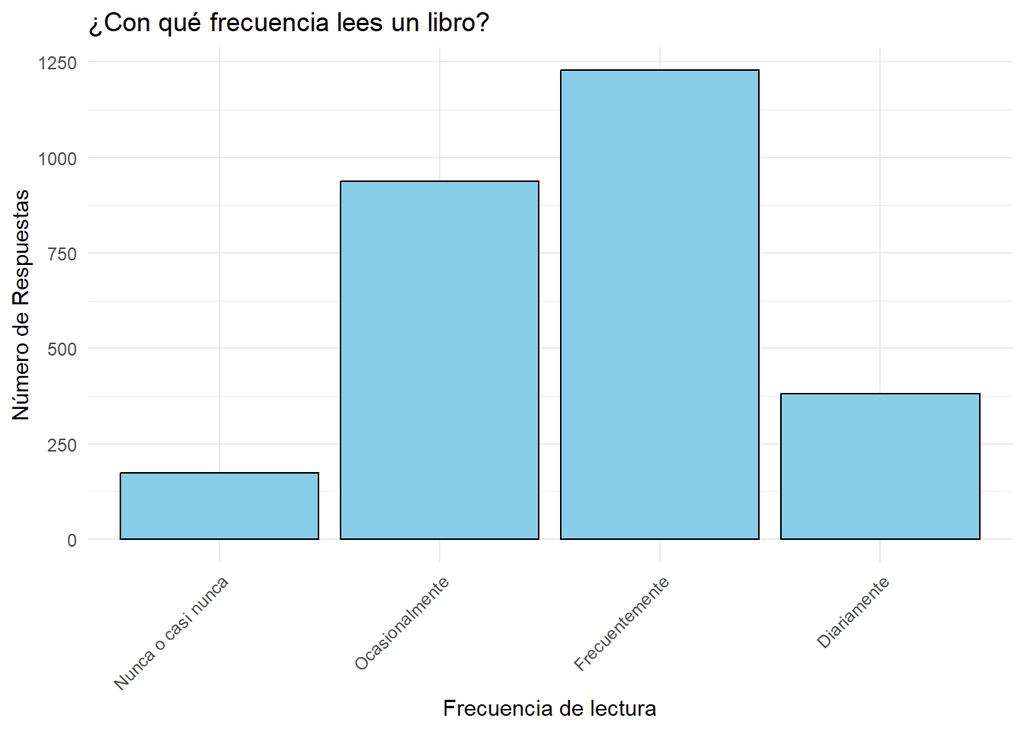

```r
library(ggplot2)
ggplot(data_lima, aes(x = factor(habito_lectura))) +
  geom_bar(fill = "skyblue", color = "black") +
  labs(title = "¿Con qué frecuencia lees un libro?",  # Título personalizado
       x = "Frecuencia de lectura",          # Etiqueta del eje X
       y = "Número de Respuestas") +        # Etiqueta del eje Y
  theme_minimal() +
  theme(axis.text.x = element_text(angle = 45, hjust = 1))  # Rotar las etiquetas para mayor legibilidad
```

```r
# Crear un vector con los nombres de las variables tal como las mencionaste
variables <- c("librosxhogar", "e_readerxhogar", "asistencia_club",
               "asistencia_biblioteca", "asistencia_festival",
               "lengua_materna", "etnia", "nivel_educ",
               "estratosocio", "sexo", "edad")

# Comprobar el tipo de cada variable dentro de 'data_lima'
for (var in variables) {
  cat(paste("Tipo de la variable", var, "es:", class(data_lima[[var]])), "\n")
}
```

```
## Tipo de la variable librosxhogar es: character
## Tipo de la variable e_readerxhogar es: character
## Tipo de la variable asistencia_club es: character
## Tipo de la variable asistencia_biblioteca es: character
## Tipo de la variable asistencia_festival es: character
## Tipo de la variable lengua_materna es: character
## Tipo de la variable etnia es: character
## Tipo de la variable nivel_educ es: character
## Tipo de la variable estratosocio es: numeric
## Tipo de la variable sexo es: numeric
## Tipo de la variable edad es: numeric
```

# PASO 3: PRUEBAS CORRELACION INDEPENDIENTES DE TODAS LAS VARIABLES

# Factorizar variables

```r
data_lima$estratosocio <- factor(
  data_lima$estratosocio,
  levels = c(6, 5, 4, 3, 2, 1),
  labels = c("Rural", "Bajo", "Medio bajo", "Medio", "Medio alto", "Alto"),
  ordered = TRUE
)
```

```r
data_lima$asistencia_club <- factor(data_lima$asistencia_club, levels = c(1, 2), labels = c("Sí", "No"))
```

```r
data_lima$asistencia_biblioteca <- factor(data_lima$asistencia_biblioteca, levels = c(1, 2), labels = c("Sí", "No"))
```

```r
data_lima$asistencia_festival <- factor(data_lima$asistencia_festival, levels = c(1, 2), labels = c("Sí", "No"))
```

```r
data_lima$lengua_materna <- recode(data_lima$lengua_materna,
                                     `1` = "Originaria",
                                     `2` = "Originaria",
                                     `3` = "Originaria",
                                     `4` = "Originaria",
                                     `5` = "Originaria",
                                     `6` = "Originaria",
                                     `7` = "Originaria",
                                     `8` = "Originaria",
                                     `9` = "Originaria",
                                     `10` = "Español",
                                     `11` = "Extranjera",
                                     `12` = "Extranjera",
                                     `13` = "Extranjera",
                                     `14` = "No escucha/no habla",
                                     `15` = "Lengua de señas")
```

```r
data_lima$lengua_materna = factor(data_lima$lengua_materna)
```

```r
data_lima$etnia = recode(data_lima$etnia,
                    `1` = "Indigena",
                    `2` = "Indigena",
                    `3` = "Indigena",
                    `4` = "Indigena",
                    `5` = "Afroperuano",
                    `6` = "Blanco",
                    `7` = "Mestizo",
                    `8` = "Otro",
                    `9` = "No sabe/No responde")

data_lima$etnia = factor(data_lima$etnia)
```

```r
data_lima$nivel_educ <- factor(
  data_lima$nivel_educ,
  levels = c(1,2,3,4,5,6,7,8,9,10,11,12),
  labels = c("Sin nivel", "Escolar", "Escolar", "Escolar", "Escolar", "Escolar", "Escolar", "Tecnica", "Tecnica", "Universitario", "Universitario", "Maestria/Doctorado"),
  ordered = TRUE
)
```

```r
data_lima$sexo <- factor(data_lima$sexo, levels = c(1, 2), labels = c("Hombre", "Mujer"))
```

```r
data_lima$e_readerxhogar = factor(data_lima$e_readerxhogar, levels = c(1, 2), labels = c("Sí", "No"))
```

#Convertir variables a numericas

```r
data_lima$librosxhogar <- as.numeric(data_lima$librosxhogar)
```

#Pruebas chi-cuadrado

```r
# Crear una lista de las variables independientes
independent_vars <- c("librosxhogar", "e_readerxhogar", "asistencia_club",
                      "asistencia_biblioteca", "asistencia_festival",
                      "lengua_materna", "etnia", "nivel_educ")

# Realizar el test de chi-cuadrado para cada variable independiente
for (var in independent_vars) {
  # Crear la tabla de contingencia
  contingency_table <- table(data_lima[[var]], data_lima$habito_lectura)

  # Realizar el test de chi-cuadrado
  chi_sq_test <- chisq.test(contingency_table)

  # Imprimir el resultado
  cat(paste("\nChi-cuadrado para", var, "y habito_lectura:\n"))
  print(chi_sq_test)
  cat("\n-----------------------------------------\n")
}
```

```
##
## Chi-cuadrado para librosxhogar y habito_lectura:
##
##  Pearson's Chi-squared test
##
## data:  contingency_table
## X-squared = 220.22, df = 228, p-value = 0.632
##
##
## -----------------------------------------
```

```
##
## Chi-cuadrado para e_readerxhogar y habito_lectura:
##
##  Pearson's Chi-squared test
##
## data:  contingency_table
## X-squared = 4.2338, df = 3, p-value = 0.2373
##
##
## -----------------------------------------
##
## Chi-cuadrado para asistencia_club y habito_lectura:
##
##  Pearson's Chi-squared test
##
## data:  contingency_table
## X-squared = 42.533, df = 3, p-value = 3.093e-09
##
##
## -----------------------------------------
##
## Chi-cuadrado para asistencia_biblioteca y habito_lectura:
##
##  Pearson's Chi-squared test
##
## data:  contingency_table
## X-squared = 34.697, df = 3, p-value = 1.412e-07
##
##
## -----------------------------------------
##
## Chi-cuadrado para asistencia_festival y habito_lectura:
##
##  Pearson's Chi-squared test
##
## data:  contingency_table
## X-squared = 12.135, df = 3, p-value = 0.006934
##
##
## -----------------------------------------
```

```
##
## Chi-cuadrado para lengua_materna y habito_lectura:
##
##  Pearson's Chi-squared test
##
## data:  contingency_table
## X-squared = 16.729, df = 9, p-value = 0.05313
##
##
## -----------------------------------------
```

```
##
## Chi-cuadrado para etnia y habito_lectura:
##
##  Pearson's Chi-squared test
##
## data:  contingency_table
## X-squared = 14.944, df = 12, p-value = 0.2445
##
##
## -----------------------------------------
```

```
##
## Chi-cuadrado para nivel_educ y habito_lectura:
##
##  Pearson's Chi-squared test
##
## data:  contingency_table
## X-squared = 58.47, df = 12, p-value = 4.283e-08
##
##
## -----------------------------------------
```

[figure not shown]

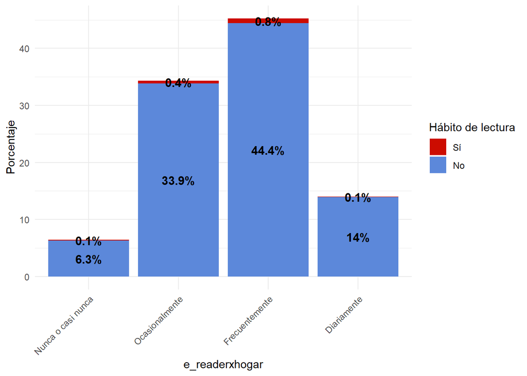

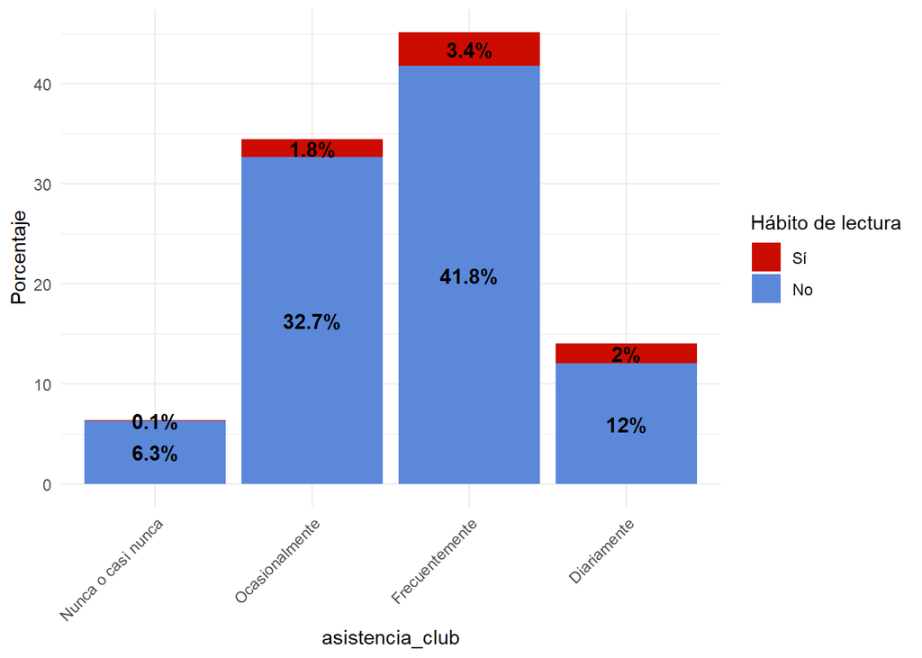

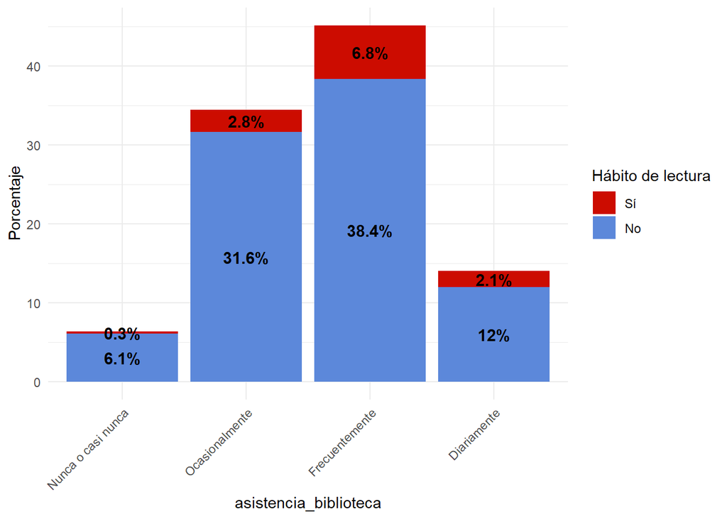

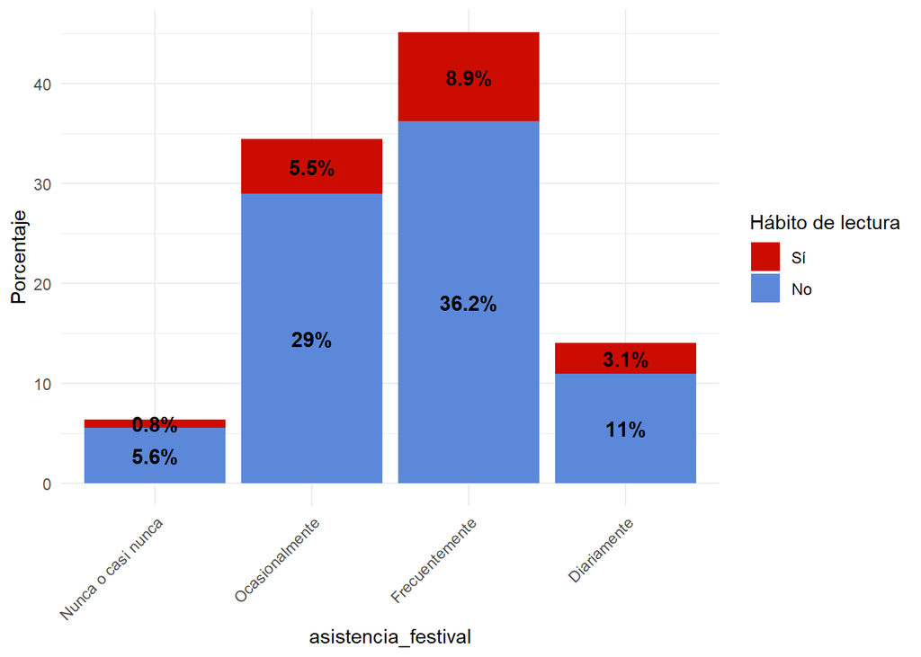

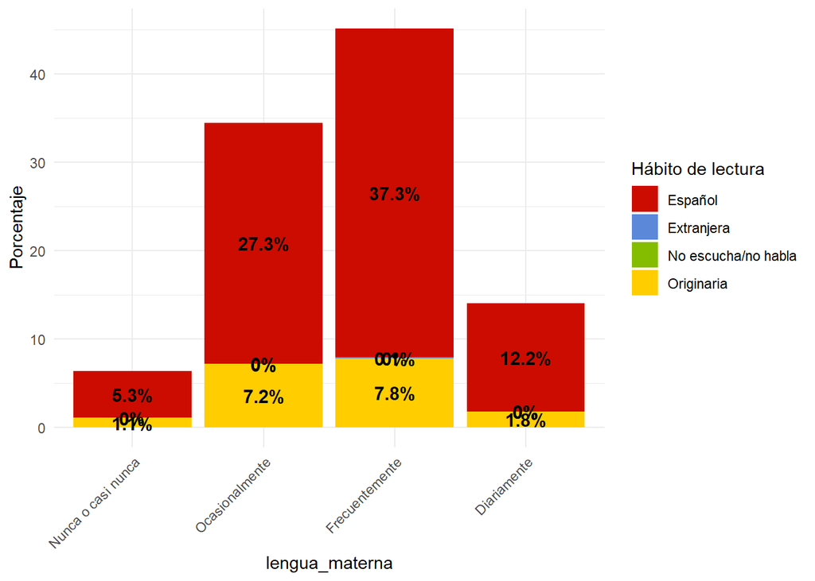

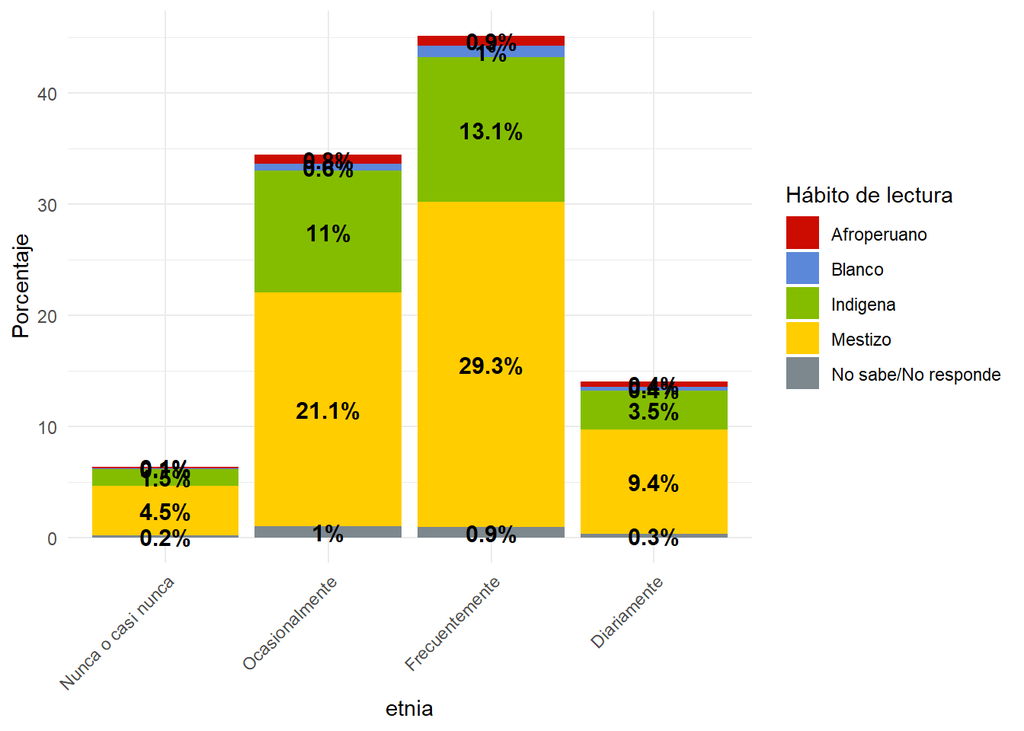

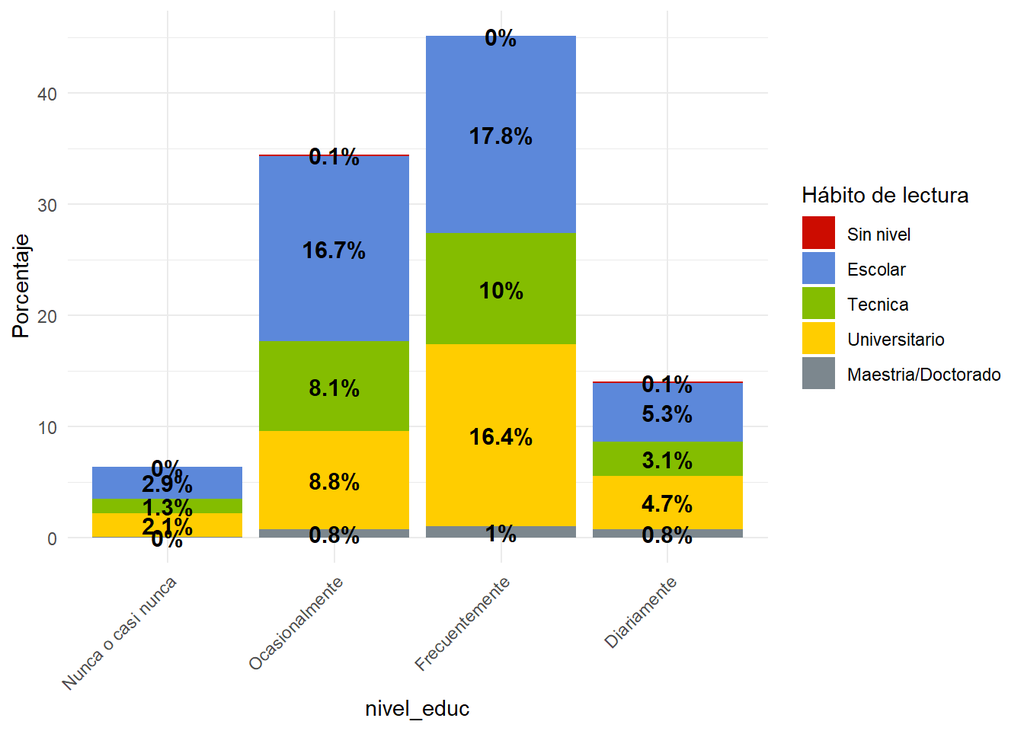

```r
library(ggplot2)
library(ggsci)  # Para usar la paleta de colores Star Trek si está instalada

# Lista de las variables independientes
independent_vars <- c("librosxhogar", "e_readerxhogar", "asistencia_club",
                      "asistencia_biblioteca", "asistencia_festival",
                      "lengua_materna", "etnia", "nivel_educ")

# Crear gráficos para cada variable independiente
for (var in independent_vars) {

  # Crear la tabla de contingencia para la variable independiente y la dependiente (habito_lectura)
  toPlot1 <- as.data.frame(table(data_lima[[var]], data_lima$habito_lectura))
  colnames(toPlot1) <- c("Categoria", var, "Frecuencia")

  # Calcular el porcentaje
  toPlot1$Porcentaje <- toPlot1$Frecuencia / sum(toPlot1$Frecuencia)

  # Crear el gráfico de barras apiladas
  p <- ggplot(toPlot1, aes(x = !!sym(var), y = Porcentaje * 100, fill = Categoria)) +
    geom_bar(position = "stack", stat = "identity") +  # Apilado de barras
    geom_text(aes(label = paste0(round(Porcentaje * 100, 1), "%")),
              position = position_stack(vjust = 0.5),
              size = 4, fontface = "bold") +
    labs(x = var, y = "Porcentaje", fill = "Hábito de lectura") +
    scale_fill_startrek() +  # Si tienes la paleta Star Trek instalada
    theme_minimal() +
    theme(axis.text.x = element_text(angle = 45, hjust = 1))  # Ajuste para los nombres del eje X

  # Mostrar el gráfico
  print(p)
}
```

#Pruebas spearman

```r
# Convertir la variable 'habito_lectura' a un factor ordenado si no lo es, y luego a numérica
data_lima$habito_lectura <- as.numeric(as.ordered(data_lima$habito_lectura))

# Lista de variables independientes numéricas
variables_independientes <- c("librosxhogar", "edad")

# Bucle para realizar la prueba de Spearman entre 'habito_lectura' y cada variable independiente
for (var in variables_independientes) {
  # Verificar si la columna existe en el dataframe
  if (!(var %in% colnames(data_lima))) {
    cat("La variable", var, "no se encuentra en el dataframe 'data_lima'.\n")
    next  # Continuar con la siguiente iteración si la variable no existe
  }

  # Verificar que la variable independiente también sea numérica
  if (!is.numeric(data_lima[[var]])) {
    cat("La variable", var, "no es numérica.\n")
    next  # Continuar con la siguiente iteración si la variable no es numérica
  }

  # Realizar la prueba de correlación de Spearman
  resultado <- cor.test(data_lima$habito_lectura, data_lima[[var]], method = "spearman")

  # Mostrar resultados
  cat("\n\nPrueba de Spearman entre 'habito_lectura' y", var, ":\n")
  print(resultado)
}
```

```
##
##
## Prueba de Spearman entre 'habito_lectura' y librosxhogar :
##
##  Spearman's rank correlation rho
##
## data:  data_lima$habito_lectura and data_lima[[var]]
## S = 3334738589, p-value = 0.1174
## alternative hypothesis: true rho is not equal to 0
## sample estimates:
##         rho
## -0.03020894
```

```
##
##
## Prueba de Spearman entre 'habito_lectura' y edad :
##
##  Spearman's rank correlation rho
##
## data:  data_lima$habito_lectura and data_lima[[var]]
## S = 3371462378, p-value = 0.7413
## alternative hypothesis: true rho is not equal to 0
## sample estimates:
##          rho
## -0.006333671
```

# PASO 4: REGRESIONES

# Modelo de regresión

```r
#Hipótesis 1: Capital Cultural y el Hábito de Lectura

#Hipótesis: Las personas que poseen un mayor capital cultural, manifestado en el acceso a libros en el hogar y la educación superior, tienen una mayor probabilidad de desarrollar un hábito de lectura frecuente ( VARIABLES P601: CANTIDAD DE LIBROS EN EL HOGAR  Y P602_5: CANTIDAD DE EQUIPOS DE LECTURA DIGITAL Y NIVEL EDUCATIVO: P306)

data_lima$nivel_educ = as.numeric(data_lima$nivel_educ)
data_lima$e_readerxhogar = as.numeric(data_lima$e_readerxhogar)
data_lima$librosxhogar = as.numeric(data_lima$librosxhogar)

modelo_regresion1 <- lm(habito_lectura ~ nivel_educ + librosxhogar + e_readerxhogar, data = data_lima)
summary(modelo_regresion1)
```

```
##
## Call:
## lm(formula = habito_lectura ~ nivel_educ + librosxhogar + e_readerxhogar,
##     data = data_lima)
##
## Residuals:
##     Min      1Q  Median      3Q     Max
## -1.8365 -0.5995  0.2434  0.4021  1.5051
##
## Coefficients:
##                  Estimate Std. Error t value Pr(>|t|)
## (Intercept)     2.2592379  0.2575667   8.771  < 2e-16 ***
## nivel_educ      0.0793423  0.0164989   4.809  1.6e-06 ***
## librosxhogar   -0.0001161  0.0001334  -0.870    0.384
## e_readerxhogar  0.0908824  0.1274102   0.713    0.476
## ---
## Signif. codes:  0 '***' 0.001 '**' 0.01 '*' 0.05 '.' 0.1 ' ' 1
##
## Residual standard error: 0.7912 on 2684 degrees of freedom
##   (31 observations deleted due to missingness)
## Multiple R-squared:  0.009089,   Adjusted R-squared:  0.007981
## F-statistic: 8.206 on 3 and 2684 DF,  p-value: 1.954e-05
```

```r
# Crear un objeto de lista para el modelo
model1 <- list("Modelo 1: Hábito de lectura" = modelo_regresion1)

# Generar un informe tabular con modelsummary y kableExtra
library(modelsummary)
modelsummary(
  model1,
  title = "Regresión: Modelo 1",
  stars = TRUE,  # Añade asteriscos a los valores significativos
  output = "kableExtra"  # Salida formateada en HTML o LaTeX
)
```

Regresión: Modelo 1

|  | Modelo 1: Hábito de lectura |
| --- | --- |
| (Intercept) | 2.259*** |
|  | (0.258) |
| nivel_educ | 0.079*** |
|  | (0.016) |
| librosxhogar | 0.000 |
|  | (0.000) |
| e_readerxhogar | 0.091 |
|  | (0.127) |
| Num.Obs. | 2688 |
| R2 | 0.009 |
| R2 Adj. | 0.008 |
| AIC | 6375.2 |
| BIC | 6404.7 |
| Log.Lik. | -3182.619 |
| F | 8.206 |
| RMSE | 0.79 |

+ p < 0.1, * p < 0.05, ** p < 0.01, *** p < 0.001

DE aqui´solo puede verse el impacto que tiene el nivel educativo, sin embargo tener más libros u aparatos no impacta en la variable.

```r
# Hipótesis 2: Capital Económico y Acceso a Recursos Culturales

# Hipótesis: Los individuos de estratos socioeconómicos más altos tienen un hábito lector más consolidado debido a su capacidad para acceder a recursos culturales como libros, e-readers y eventos literarios.( RELACIONADO CON LA VARIABLE "estratosocio")

data_lima$estratosocio = as.numeric(data_lima$estratosocio)
modelo_regresion2 <- lm(habito_lectura ~ nivel_educ + estratosocio, data = data_lima)
summary(modelo_regresion2)
```

```
##
## Call:
## lm(formula = habito_lectura ~ nivel_educ + estratosocio, data = data_lima)
##
## Residuals:
##     Min      1Q  Median      3Q     Max
## -1.8532 -0.6312  0.2424  0.4030  1.4987
##
## Coefficients:
##              Estimate Std. Error t value Pr(>|t|)
## (Intercept)   2.37499    0.05668  41.902  < 2e-16 ***
## nivel_educ    0.06495    0.01737   3.739 0.000189 ***
## estratosocio  0.03070    0.01292   2.376 0.017592 *
## ---
## Signif. codes:  0 '***' 0.001 '**' 0.01 '*' 0.05 '.' 0.1 ' ' 1
##
## Residual standard error: 0.7895 on 2716 degrees of freedom
## Multiple R-squared:  0.01052,    Adjusted R-squared:  0.009787
## F-statistic: 14.43 on 2 and 2716 DF,  p-value: 5.827e-07
```

```r
model2 <- list("Modelo 2: Apropiación (II)" = modelo_regresion2)

# Generar un informe tabular con modelsummary y kableExtra
library(modelsummary)
modelsummary(
  model2,
  title = "Regresión: Modelo 2",
  stars = TRUE,  # Añade asteriscos para denotar significancia estadística
  output = "kableExtra"  # Salida formateada (HTML o LaTeX)
)
```

Regresión: Modelo 2

|  | &nbsp;Modelo 2: Apropiación (II) |
| --- | --- |
| (Intercept) | 2.375*** |
|  | (0.057) |
| nivel_educ | 0.065*** |
|  | (0.017) |
| estratosocio | 0.031* |
|  | (0.013) |
| Num.Obs. | 2719 |
| R2 | 0.011 |
| R2 Adj. | 0.010 |
| AIC | 6435.7 |
| BIC | 6459.3 |
| Log.Lik. | -3213.839 |
| F | 14.432 |
| RMSE | 0.79 |

+ p < 0.1, * p < 0.05, ** p < 0.01, *** p < 0.001

Aquí se puede ver que las 2 variables ( tanto nivel educativo como nivel socioeconomico)tienen un impacto significativo en la variable dependiente. Por un lado, el nivel educativo podria ayudar a generar un hábito lector puesto que cada vez que superas un nivel, hay mayor cantidad de lecturas o variedad de estas por lo que un estudiante univrsitario podria hallar temas de interés que le incentiven a generar este hábito. Por otro lado, nivel socioeconomico influye ( aunque no fuertemente) en el hábito de lectura puesto que a mayor oportunidades de estudio, más dinero o tiempo permiten a la persona centrarse en actividades de su interés ( en este caso la lectura)

```r
# Hipótesis 3: Capital Social y Participación en Actividades Literarias

# Hipótesis: La participación en actividades literarias, como clubes de lectura y festivales, influye positivamente en el hábito lector gracias al capital social acumulado por el individuo.( RELACIONADO A LAS VARIABLES ASISTENCIA A ESPACIOS CULTURALES)

data_lima$asistencia_biblioteca = as.numeric(data_lima$asistencia_biblioteca)
data_lima$asistencia_club = as.numeric(data_lima$asistencia_club)
data_lima$asistencia_festival = as.numeric(data_lima$asistencia_festival)

modelo_regresion3 <- lm(habito_lectura ~  asistencia_club + asistencia_biblioteca +
                       asistencia_festival, data = data_lima)
summary(modelo_regresion3)
```

```
##
## Call:
## lm(formula = habito_lectura ~ asistencia_club + asistencia_biblioteca +
##     asistencia_festival, data = data_lima)
##
## Residuals:
##     Min      1Q  Median      3Q     Max
## -1.9230 -0.6053  0.1905  0.3947  1.3947
##
## Coefficients:
##                       Estimate Std. Error t value Pr(>|t|)
## (Intercept)            3.81940    0.14374  26.571  < 2e-16 ***
## asistencia_club       -0.31773    0.05878  -5.405 7.04e-08 ***
## asistencia_biblioteca -0.20425    0.04705  -4.341 1.47e-05 ***
## asistencia_festival   -0.08509    0.03953  -2.152   0.0315 *
## ---
## Signif. codes:  0 '***' 0.001 '**' 0.01 '*' 0.05 '.' 0.1 ' ' 1
##
## Residual standard error: 0.7844 on 2715 degrees of freedom
## Multiple R-squared:  0.02351,    Adjusted R-squared:  0.02243
## F-statistic: 21.79 on 3 and 2715 DF,  p-value: 6.122e-14
```

```r
model3 <- list("Modelo 3: Influencia de la Asistencia" = modelo_regresion3)

# Generar un informe tabular con modelsummary y kableExtra
library(modelsummary)
modelsummary(
  model3,
  title = "Regresión: Modelo 3",
  stars = TRUE,  # Añade asteriscos para denotar significancia estadística
  output = "kableExtra"  # Salida formateada (HTML o LaTeX)
)
```

Regresión: Modelo 3

|  | &nbsp;Modelo 3: Influencia de la Asistencia |
| --- | --- |
| (Intercept) | 3.819*** |
|  | (0.144) |
| asistencia_club | -0.318*** |
|  | (0.059) |
| asistencia_biblioteca | -0.204*** |
|  | (0.047) |
| asistencia_festival | -0.085* |
|  | (0.040) |
| Num.Obs. | 2719 |
| R2 | 0.024 |
| R2 Adj. | 0.022 |
| AIC | 6401.7 |
| BIC | 6431.3 |
| Log.Lik. | -3195.871 |
| F | 21.786 |
| RMSE | 0.78 |

+ p < 0.1, * p < 0.05, ** p < 0.01, *** p < 0.001

Aquí se puede visualizar que todas las variables tienen un impacto significativo en la variable dependiente por lo que se puede deducir que al asistir a más actividades relacionadas a la lectura o interacción sobre libros o la promoción de estos puede ayudar a generar un hábito lector.

```r
# Hipótesis 4: Lengua Materna y el Desarrollo del Hábito Lector

# Hipótesis: Las personas cuya lengua materna coincide con la lengua predominante en la producción literaria de su entorno tienen un mayor hábito lector debido a un capital cultural más accesible.( RELACIONADO CON LAS VARIABLES P301=LENGUA MATERNA Y P303=ETNIA)

data_lima$etnia = as.numeric(data_lima$etnia)
data_lima$lengua_materna = as.numeric(data_lima$lengua_materna)
modelo_regresion4 <- lm(habito_lectura ~ edad + etnia + lengua_materna, data = data_lima)
summary(modelo_regresion4)
```

```
##
## Call:
## lm(formula = habito_lectura ~ edad + etnia + lengua_materna,
##     data = data_lima)
##
## Residuals:
##     Min      1Q  Median      3Q     Max
## -1.7937 -0.6736  0.3009  0.3391  1.4731
##
## Coefficients:
##                 Estimate Std. Error t value Pr(>|t|)
## (Intercept)     2.819654   0.105101  26.828  < 2e-16 ***
## edad            0.001062   0.001198   0.887  0.37516
## etnia          -0.033654   0.023836  -1.412  0.15809
## lengua_materna -0.044317   0.014167  -3.128  0.00178 **
## ---
## Signif. codes:  0 '***' 0.001 '**' 0.01 '*' 0.05 '.' 0.1 ' ' 1
##
## Residual standard error: 0.7923 on 2715 degrees of freedom
## Multiple R-squared:  0.003761,   Adjusted R-squared:  0.00266
## F-statistic: 3.416 on 3 and 2715 DF,  p-value: 0.01669
```

```r
model4 <- list("Modelo 4: Factores Socioculturales" = modelo_regresion4)

# Generar un informe tabular con modelsummary y kableExtra
library(modelsummary)
modelsummary(
  model4,
  title = "Regresión: Modelo 4",
  stars = TRUE,  # Añade asteriscos para denotar significancia estadística
  output = "kableExtra"  # Salida formateada (HTML o LaTeX)
)
```

Regresión: Modelo 4

|  | &nbsp;Modelo 4: Factores Socioculturales |
| --- | --- |
| (Intercept) | 2.820*** |
|  | (0.105) |
| edad | 0.001 |
|  | (0.001) |
| etnia | -0.034 |
|  | (0.024) |
| lengua_materna | -0.044** |
|  | (0.014) |
| Num.Obs. | 2719 |
| R2 | 0.004 |
| R2 Adj. | 0.003 |
| AIC | 6456.2 |
| BIC | 6485.7 |
| Log.Lik. | -3223.088 |
| F | 3.416 |
| RMSE | 0.79 |

+ p < 0.1, * p < 0.05, ** p < 0.01, *** p < 0.001

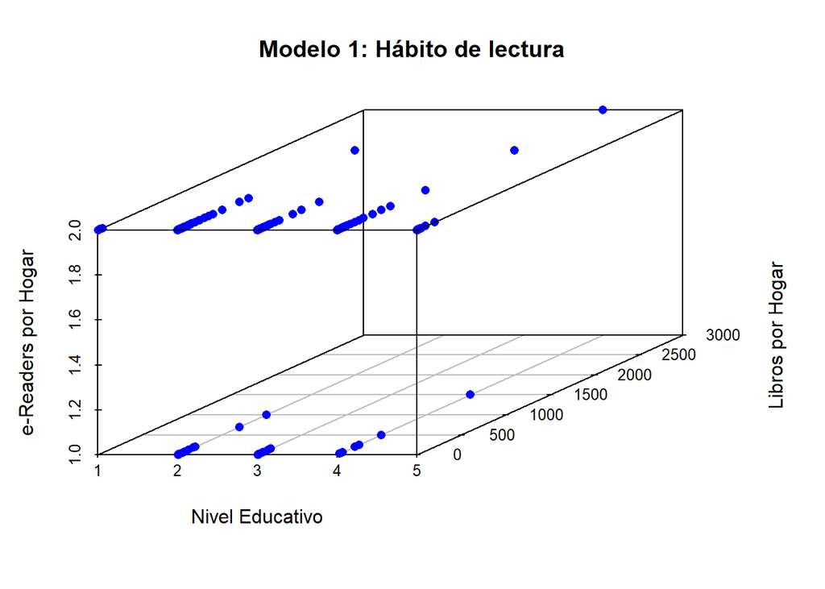

```r
library(scatterplot3d)

# Modelo 1: Variables incluidas en el modelo
scatterplot3d(
  x = data_lima$nivel_educ,
  y = data_lima$librosxhogar,
  z = data_lima$e_readerxhogar,
  color = "blue",
  pch = 16,
  main = "Modelo 1: Hábito de lectura",
  xlab = "Nivel Educativo",
  ylab = "Libros por Hogar",
  zlab = "e-Readers por Hogar"
)
```

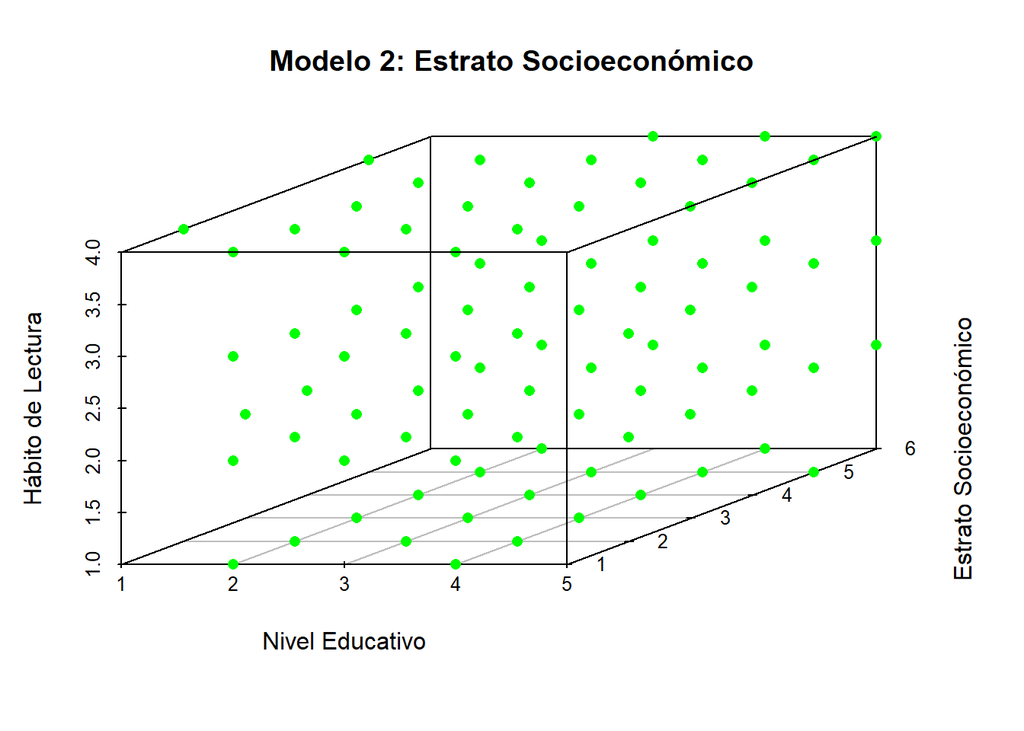

```r
# Modelo 2: Variables incluidas en el modelo
scatterplot3d(
  x = data_lima$nivel_educ,
  y = data_lima$estratosocio,
  z = data_lima$habito_lectura,
  color = "green",
  pch = 16,
  main = "Modelo 2: Estrato Socioeconómico",
  xlab = "Nivel Educativo",
  ylab = "Estrato Socioeconómico",
  zlab = "Hábito de Lectura"
)
```

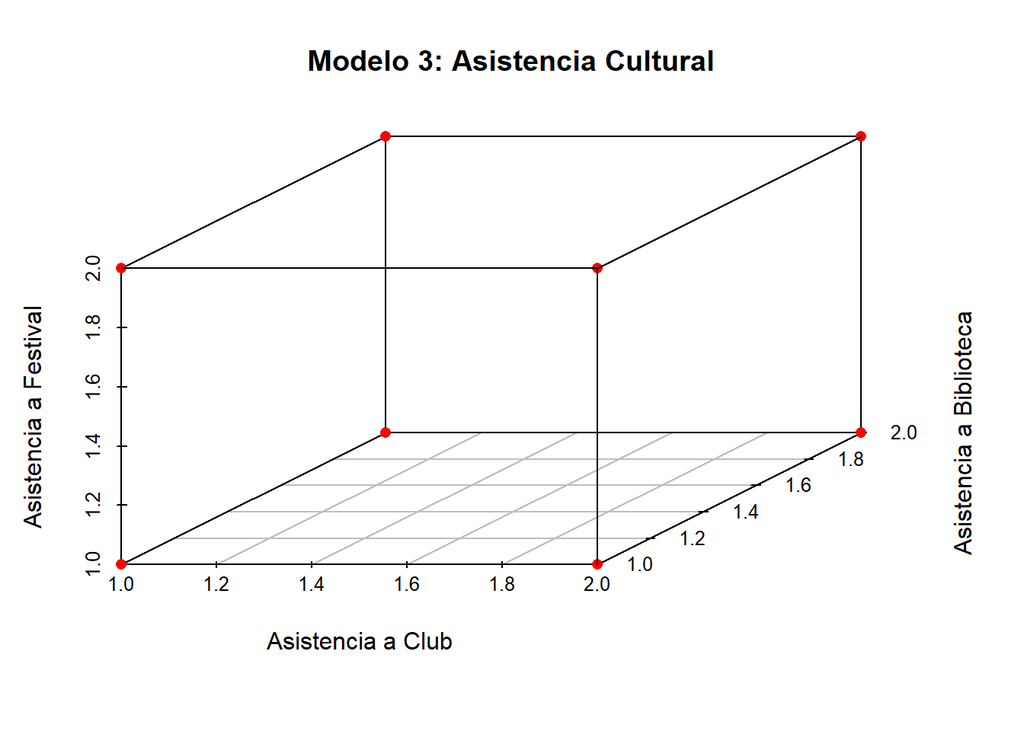

```r
# Modelo 3: Variables incluidas en el modelo
scatterplot3d(
  x = data_lima$asistencia_club,
  y = data_lima$asistencia_biblioteca,
  z = data_lima$asistencia_festival,
  color = "red",
  pch = 16,
  main = "Modelo 3: Asistencia Cultural",
  xlab = "Asistencia a Club",
  ylab = "Asistencia a Biblioteca",
  zlab = "Asistencia a Festival"
)
```

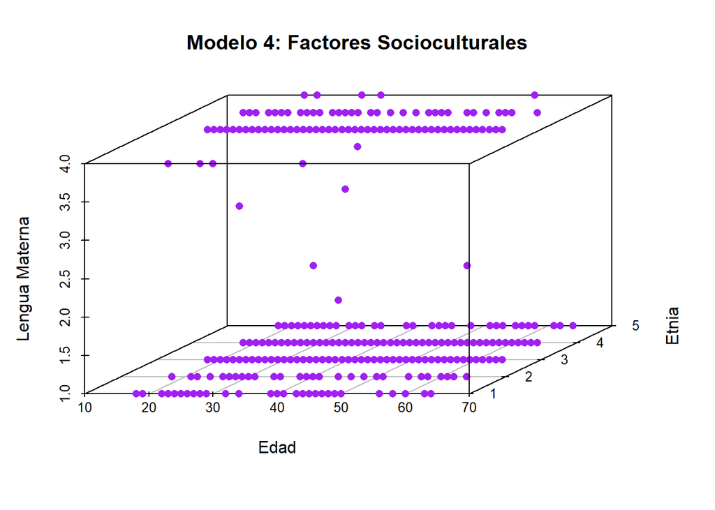

```r
library(scatterplot3d)

# Modelo 4: Variables incluidas en el modelo
scatterplot3d(
  x = data_lima$edad,
  y = data_lima$etnia,
  z = data_lima$lengua_materna,
  color = "purple",
  pch = 16,
  main = "Modelo 4: Factores Socioculturales",
  xlab = "Edad",
  ylab = "Etnia",
  zlab = "Lengua Materna"
)
```

```r
# PASO 4: ANALISIS DE CLUSTER
library(cluster)
```

```r
# Selección de las variables que se usarán en el análisis de clúster
datos_clust <- data_lima[, c("habito_lectura", "librosxhogar", "e_readerxhogar"
                        , "asistencia_club", "asistencia_biblioteca",
                        "asistencia_festival", "lengua_materna", "etnia",
                        "nivel_educ", "estratosocio", "sexo","edad")]

# Convertir todas las variables a numéricas

datos_clust <- as.data.frame(lapply(datos_clust, as.numeric))


# Normalizar los datos (es recomendable)
datos_clust_norm <- scale(datos_clust)
```

```r
# Número de clústeres que quieres obtener, por ejemplo, 3
set.seed(123)  # Para hacer que los resultados sean reproducibles
pam_result <- pam(datos_clust_norm, k = 3)  # Cambia el valor de k según sea necesario

# Ver los resultados del análisis PAM
pam_result$medoids  # Medoids (centros de los clústeres)
```

```
##      habito_lectura librosxhogar e_readerxhogar asistencia_club
## [1,]      0.4181443  -0.12465520      0.1228825       0.2794349
## [2,]      0.4181443  -0.08143891      0.1228825       0.2794349
## [3,]     -0.8423150           NA             NA       0.2794349
##      asistencia_biblioteca asistencia_festival lengua_materna      etnia
## [1,]             0.3683831           0.4728532     -0.4672833  0.5524308
## [2,]             0.3683831           0.4728532     -0.4672833  0.5524308
## [3,]             0.3683831           0.4728532      2.1452112 -0.9201764
##       nivel_educ estratosocio       sexo        edad
## [1,]  0.06277761   -0.2642484  0.9120878 -0.11210096
## [2,]  0.06277761   -0.2642484 -1.0959824 -0.03372541
## [3,] -1.01755351   -0.2642484  0.9120878  1.29865888
```

```r
pam_result$clustering  # Asignación de cada observación a un clúster
```

[output not shown]

[output cut: 59 more lines]

```r
pam_result$silinfo  # Información sobre la silueta (para ver qué tan bien definidos están los clústeres)
```

[output not shown]

[output cut: 2712 more lines]

```r
# Seleccionar las columnas relevantes
datos_clust <- data_lima[, c("habito_lectura", "librosxhogar", "e_readerxhogar",
                             "asistencia_club", "asistencia_biblioteca",
                             "asistencia_festival", "lengua_materna", "etnia",
                             "nivel_educ", "estratosocio", "sexo", "edad")]

# Verificar clases de cada columna
clases <- sapply(datos_clust, class)
print(clases) # Para revisar las columnas que no son numéricas
```

```
##        habito_lectura          librosxhogar        e_readerxhogar
##             "numeric"             "numeric"             "numeric"
##       asistencia_club asistencia_biblioteca   asistencia_festival
##             "numeric"             "numeric"             "numeric"
##        lengua_materna                 etnia            nivel_educ
##             "numeric"             "numeric"             "numeric"
##          estratosocio                  sexo                  edad
##             "numeric"              "factor"             "numeric"
```

```r
# Convertir factores o caracteres a numéricos
datos_clust[] <- lapply(datos_clust, function(col) {
  if (is.factor(col) || is.character(col)) {
    as.numeric(as.factor(col)) # Convertir a numérico
  } else {
    col # Dejar numéricos como están
  }
})

# Verificar si todas las columnas son numéricas
clases_post_conversion <- sapply(datos_clust, class)
print(clases_post_conversion)
```

```
##        habito_lectura          librosxhogar        e_readerxhogar
##             "numeric"             "numeric"             "numeric"
##       asistencia_club asistencia_biblioteca   asistencia_festival
##             "numeric"             "numeric"             "numeric"
##        lengua_materna                 etnia            nivel_educ
##             "numeric"             "numeric"             "numeric"
##          estratosocio                  sexo                  edad
##             "numeric"             "numeric"             "numeric"
```

```r
# Eliminar filas con valores faltantes (opcional, si hay NA)
datos_clust <- na.omit(datos_clust)

# Normalizar los datos
datos_clust_norm <- scale(datos_clust)

# Verificar resultados
head(datos_clust_norm)
```

```
##      habito_lectura librosxhogar e_readerxhogar asistencia_club
## [1,]      0.4172662  -0.33209339      0.1228825       0.2811677
## [2,]      1.6760895  -0.33209339      0.1228825       0.2811677
## [3,]      0.4172662  -0.25430407      0.1228825       0.2811677
## [4,]      0.4172662   0.09142625      0.1228825       0.2811677
## [5,]      0.4172662  -0.29752036      0.1228825       0.2811677
## [6,]      0.4172662  -0.12465520      0.1228825       0.2811677
##      asistencia_biblioteca asistencia_festival lengua_materna     etnia
## [1,]             0.3694919          -2.1096626     -0.4658387 2.0279578
## [2,]             0.3694919           0.4738331     -0.4658387 0.5518813
## [3,]            -2.7054126           0.4738331     -0.4658387 0.5518813
## [4,]            -2.7054126           0.4738331     -0.4658387 0.5518813
## [5,]             0.3694919           0.4738331     -0.4658387 0.5518813
## [6,]             0.3694919          -2.1096626     -0.4658387 0.5518813
##      nivel_educ estratosocio       sexo       edad
## [1,] 1.14267548     1.343121  0.9141961  0.6708440
## [2,] 0.06229852     1.343121  0.9141961 -0.8178088
## [3,] 2.22305244     1.343121  0.9141961 -0.2693578
## [4,] 2.22305244     1.343121 -1.0934503  1.6893958
## [5,] 1.14267548     1.343121  0.9141961 -1.1312093
## [6,] 1.14267548     1.343121 -1.0934503 -1.3662598
```

```r
# Instalar y cargar las librerías necesarias

library(cluster)
library(factoextra)
# Aplicar el algoritmo PAM
set.seed(123) # Para reproducibilidad
pam_result <- pam(datos_clust_norm, k = 3) # Cambia 'k' por el número de clusters deseados
```

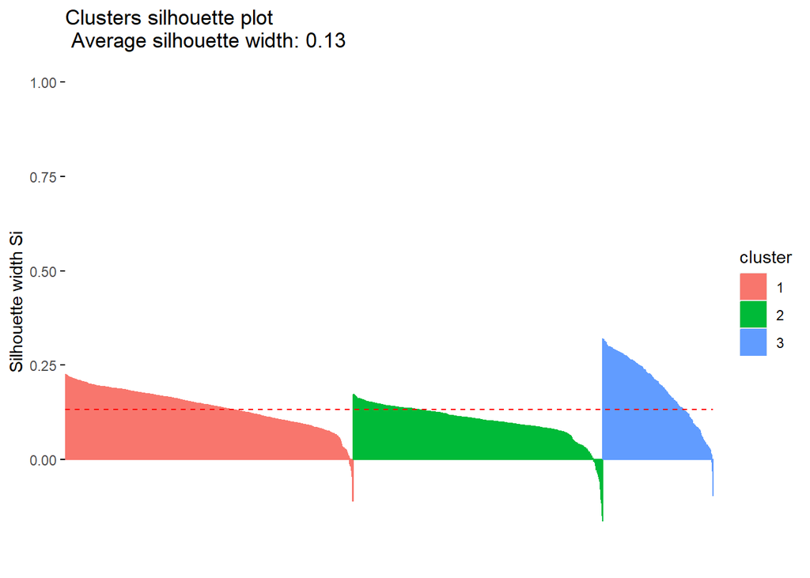

```r
# Visualizar el gráfico de silueta
fviz_silhouette(pam_result, print.summary = FALSE)
```